# WeRateDogs - Query Twitter Data

- I. - Explanatory Analysis
- II. - Conclusions
- II. - References

## I. - Explanatory Analysis

WeRateDogs® is a popular twitter blog, which tweets on a daily basis. A very important question for each blogger is: What drives my popularity?

In the following analysis we want to dive into the number and answer simple but important questions. Popularity is measured by number of favorites or - more important - number of retweets. [Why are retweets more important?](https://medium.com/@Encore/favorites-vs-retweets-and-why-one-is-more-important-than-the-other-ba12ee20e9ba) For these reasons we will focus on number of retweets in this analysis.

##### 2. Do some breeds outperform others?

Do some breeds receive a significant higher popularity and if so which breed is the most popular?

```python
df_analysis = pd.read_csv('cleaned_data.csv', index_col=['tweet_id'], parse_dates=['timestamp'])
```

##### 1. When is the best time for a tweet?

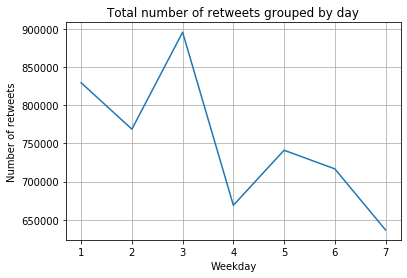

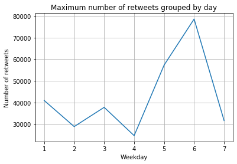

```python
aggr_weekday_sum = df_analysis.groupby('weekday').retweet_count.sum()

aggr_weekday_sum.plot();
plt.grid(which='major', axis='both')
plt.title('Total number of retweets grouped by day')
plt.ylabel('Number of retweets')
plt.xlabel('Weekday')
plt.show()
plt.clf;

aggr_weekday_max = df_analysis.groupby('weekday').retweet_count.max()

aggr_weekday_max.plot();
plt.grid(which='major', axis='both')
plt.title('Maximum number of retweets grouped by day')
plt.ylabel('Number of retweets')
plt.xlabel('Weekday')
plt.show()
plt.clf;
```

By looking at the first plot, we see that the best day for tweeting is Wednesday, followed by Monday. This is interesting because my first guess would have been saturday, since people have more free time compared to working days. On the other hand, Saturday is the day most popular tweet overall, as can be seen in the second plot. Hence, we checked the retweet volatility in the next two plots,to validate these result.

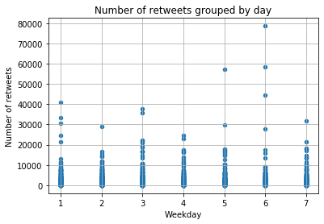

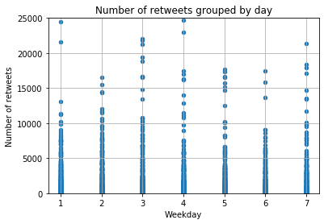

```python
df_analysis.plot.scatter(x='weekday', y='retweet_count')
plt.grid(which='major', axis='both')
plt.title('Number of retweets grouped by day')
plt.ylabel('Number of retweets')
plt.xlabel('Weekday')
plt.show()
plt.clf;

df_analysis.plot.scatter(x='weekday', y='retweet_count')
plt.grid(which='major', axis='both')
plt.title('Number of retweets grouped by day')
plt.ylabel('Number of retweets')
plt.xlabel('Weekday')
plt.ylim([0,25000])
plt.show()
plt.clf;
```

The first plot suggests that volatility decreases. However, if we remove outliers the story is diffrent. In the second plot we see that tweets during weekdays perform better than tweets during weekends. Moreover, volatility seems to be almost constant.

**To check the results, an A|B test was performed.**

```python
weekday_df = []

for _ in range(10000):
    weekday_df.append({'weekdays':df_analysis.sample(2500, replace=True).query('weekday<6').retweet_count.mean(),
               'weekends':df_analysis.sample(2500, replace=True).query('weekday>5').retweet_count.mean(),
               'mean_diff':df_analysis.sample(2500, replace=True).query('weekday<6').retweet_count.mean() - df_analysis.sample(2500, replace=True).query('weekday>5').retweet_count.mean()})

weekday_df = pd.DataFrame(weekday_df)
```

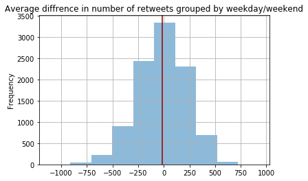

```
Mean diffrence: -15.590203619718997
```

```python
plt.hist(weekday_df['mean_diff'], alpha = 0.5, label='weekdays')
plt.axvline(weekday_df['mean_diff'].mean(), color='darkred')

plt.title('Average diffrence in number of retweets grouped by weekday/weekend')
plt.xlabel=('Average number of retweets')
plt.ylabel('Frequency')
plt.grid(True, which='major', axis='both')

plt.show()

print('Mean diffrence: '+str(weekday_df['mean_diff'].mean()))
```

The A|B test contradicts our previous results and shows that there is no statistical significant diffrence in number of retweets - and by far no practical significance. Thus, we conclude that the day doens't matter when tweeting. **It seems like tweets spread over time, an information not covered in our analysis - future research has to proove this hypothesis.**

##### 2. Do some breeds outperform others?

Is there a dog breed, which is more popular in general and lead to more popular tweets. This question is answered by the following bar plot, which shows the total number of retweets per breed for the five most popular breeds.

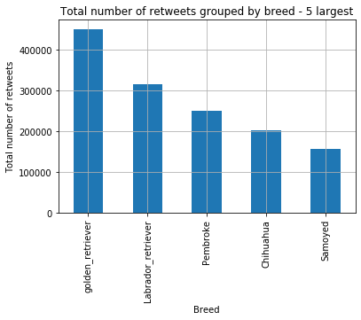

```python
aggr_pred = df_analysis.groupby('p1').retweet_count.sum().nlargest(5)

aggr_pred.plot.bar();
plt.grid(which='major', axis='both')
plt.title('Total number of retweets grouped by breed - 5 largest')
plt.ylabel('Total number of retweets')
plt.xlabel('Breed')
plt.show()
plt.clf;
```

**The most popular breeds are:**

| Rank | Dog breed |
| --- | --- |
| 1 | Golden Retriever |
| 2 | Labrador Retriever |
| 3 | Welsh Corgi Pembroke |
| 4 | Chihuahua |
| 5 | Samoyed |

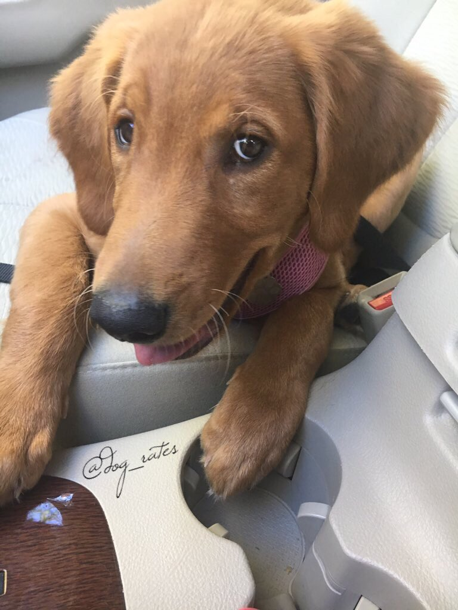

```python
golden_retriever = df_analysis[df_analysis['p1']=='golden_retriever']

random_retriever = random.choice(golden_retriever[golden_retriever.expanded_urls_add.notnull()].expanded_urls_add.values)
Image(url=random_retriever, embed=True, width=260, height=260)
```

## II. - Conclusions

**1. There is no significant diffrence between tweeting during working week or tweeting during the weekend.**

**3. However, every blog should offer diversity - every now and then a golden retriever!**

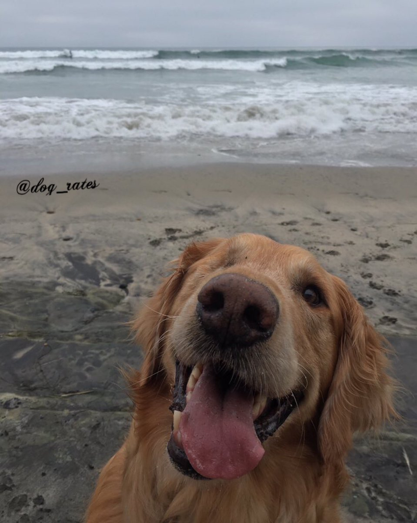

```python
golden_retriever = df_analysis[df_analysis['p1']=='golden_retriever']

random_retriever = random.choice(golden_retriever[golden_retriever.expanded_urls_add.notnull()].expanded_urls_add.values)
Image(url=random_retriever, embed=True, width=260, height=260)
```

## III. - References

- [Writing to a JSOn file](https://stackabuse.com/reading-and-writing-json-to-a-file-in-python/)
- [Tweepy Error Messages](https://www.programcreek.com/python/example/13279/tweepy.TweepError)
- [Flatten Nested JSON files](https://towardsdatascience.com/how-to-flatten-deeply-nested-json-objects-in-non-recursive-elegant-python-55f96533103d)
- [Why are retweets more important?](https://medium.com/@Encore/favorites-vs-retweets-and-why-one-is-more-important-than-the-other-ba12ee20e9ba)